# ML2_Code_Notes

Giang Nguyen

12/31/2019

# 1 Regression Tree using `tree` package

```r
library(tree)
```

## 1.1 Data - Boston dataset

**Target variable**  
MEDV - Median value of owner-occupied homes in $1000’s  
**Available predictors**  
* CRIM - per capita crime rate by town  
* ZN - proportion of residential land zoned for lots over 25,000 sq.ft.  
* INDUS - proportion of non-retail business acres per town.  
* CHAS - Charles River dummy variable (1 if tract bounds river; 0 otherwise)  
* NOX - nitric oxides concentration (parts per 10 million)  
* RM - average number of rooms per dwelling  
* AGE - proportion of owner-occupied units built prior to 1940  
* DIS - weighted distances to five Boston employment centres  
* RAD - index of accessibility to radial highways  
* TAX - full-value property-tax rate per $10,000  
* PTRATIO - pupil-teacher ratio by town  
* B - 1000(Bk - 0.63)^2 where Bk is the proportion of blacks by town  
* LSTAT - % lower status of the population

## 1.2 Divide data into train-test set

Use `sample()` function, which take 3 arguments:  
- a range of row index  
- size of the sample  
- replace = TRUE/FALSE for drawing sample with/without replacement.

```r
set.seed(1)
Boston.train = sample(1:nrow(Boston), size = nrow(Boston)/2, replace = FALSE)
```

## 1.3 Create a formula which states which predictors to be included

```r
Boston_formula = medv ~. # . = all predictors
```

## 1.4 Fitting a tree

Use funtion `tree()` from `tree` package. Use `summary(tree)` to show summary of tree, such as how many variables are used in the tree, how many nodes and distribution of the residuals.

```r
Boston.tree = tree(Boston_formula,
                   data = Boston,
                   subset = Boston.train)
#summary tree
summary(Boston.tree)
```

```
##
## Regression tree:
## tree(formula = Boston_formula, data = Boston, subset = Boston.train)
## Variables actually used in tree construction:
## [1] "rm"    "lstat" "crim"  "age"
## Number of terminal nodes:  7
## Residual mean deviance:  10.38 = 2555 / 246
## Distribution of residuals:
##     Min.  1st Qu.   Median     Mean  3rd Qu.     Max.
## -10.1800  -1.7770  -0.1775   0.0000   1.9230  16.5800
```

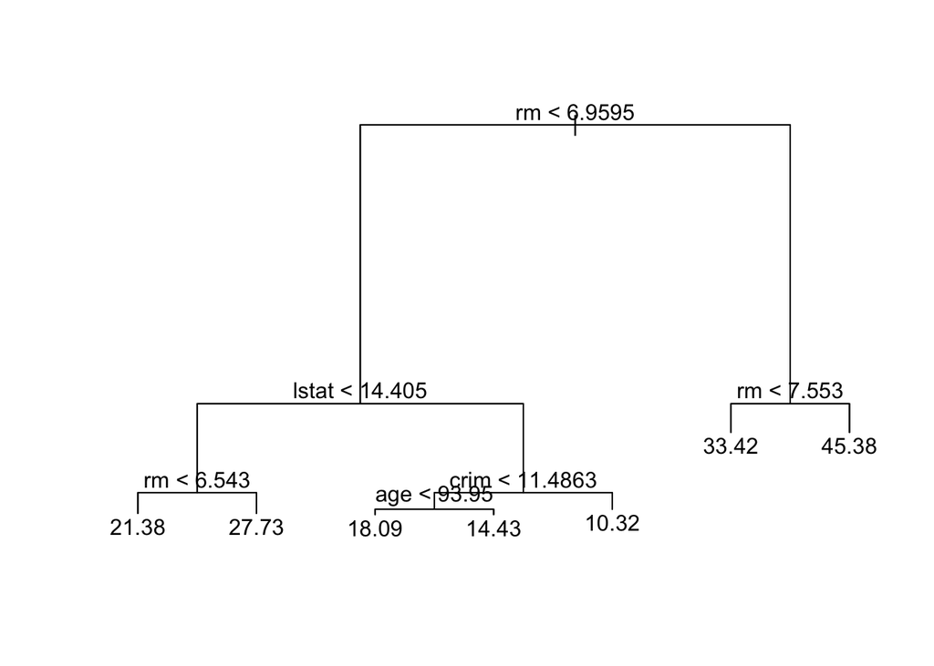

```r
#plot tree
plot(Boston.tree)
text(Boston.tree, pretty = 0)
```

## 1.5 K-fold cross-validation to determine the appropriate tree size

Use `tree::cv.tree()` function to perform cross-validation.

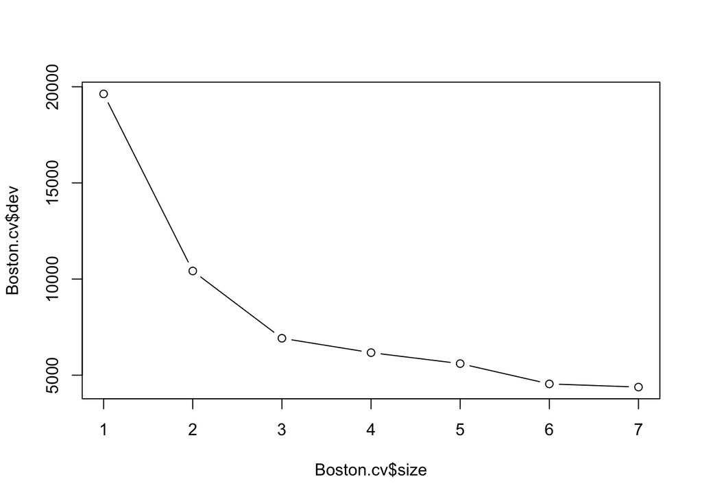

```r
Boston.cv = cv.tree(Boston.tree, #tree object
                    K = 10 # number of K-folds
                    )
plot(Boston.cv$size, #tree size
     Boston.cv$dev, # deviation
     type = 'b' #line plot
     )
```

## 1.6 Prune the tree

Base on the olot,assume the appropriate number of terminal nodes is 5. Use function `tree::prune.tree()` to prune the tree.

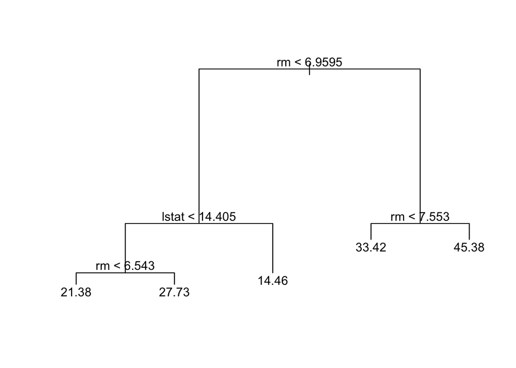

```r
Boston.tree.pruned = prune.tree(Boston.tree, #original tree object
                                best = 5 # number of terminal nodes.
                                )

plot(Boston.tree.pruned)
text(Boston.tree.pruned, pretty = 0)
```

## 1.7 Use tree to predict

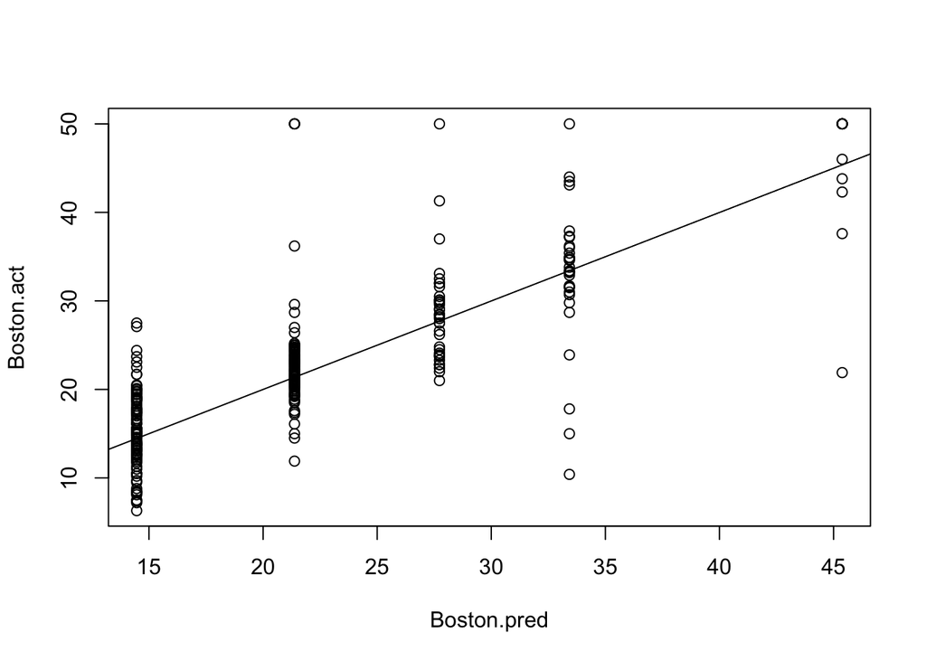

```r
Boston.pred = predict(Boston.tree.pruned,
                      newdata = Boston[-Boston.train, ]
                      )
Boston.act = Boston[-Boston.train, 'medv']
plot(Boston.pred, Boston.act)
abline(0,1)
```

```r
# MSE - mean squared error
mean((Boston.pred-Boston.act)**2)
```

```
## [1] 35.90102
```

# 2 Regression Tree using `caret` & `rpart` package

`rpart` : Recursive Partitioning and Regression Tree

```r
library(caret)
```

## 2.1 Divide data into train-test set

```r
trainset = caret::createDataPartition(Boston$medv,
                               p = 0.7, # % of train set
                               list = FALSE # if TRUE return a list, else return a matrix
                               )
data.train = Boston[trainset,]
data.test = Boston[-trainset,]
```

## 2.2 Create a formula which states which predictors to be included

```r
Boston_formula = medv ~. # . = all predictors
```

## 2.3 Fitting a tree

`rpart()` return more details than `tree()`,including information about variable importance, bot best split and surogate plit, which is alternative split which use altenative subsets of predictions and yield results close to the train dataset. Details of the tree can be shown by `summary(tree)`  
`rpart` also offer better visualization of the tree.

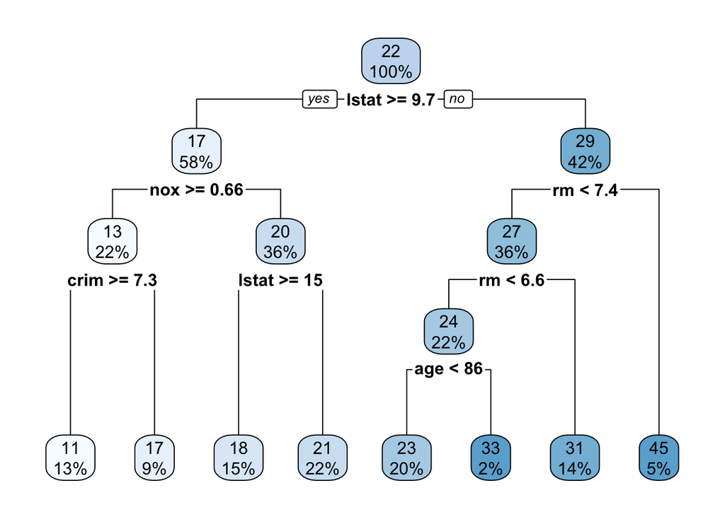

```r
boston.tree = rpart::rpart(formula = Boston_formula,
                           data = data.train)

# summmary of the tree
# summary(boston.tree)

# plot the tree
rpart.plot::rpart.plot(boston.tree)
```

## 2.4 K-fold cross-validation to determine the appropriate tree size

- Configure the cross-validation using `caret::trainControl()`
- Create a dataframe with columns are named the same as the tuning parameter.  
  To tune the tree complexity (cp or $\alpha$) in the cost function: $S(\alpha,T) = Q(T) + \alpha  |T|$, where $Q(T)$ is the Sum of Squared Errors.

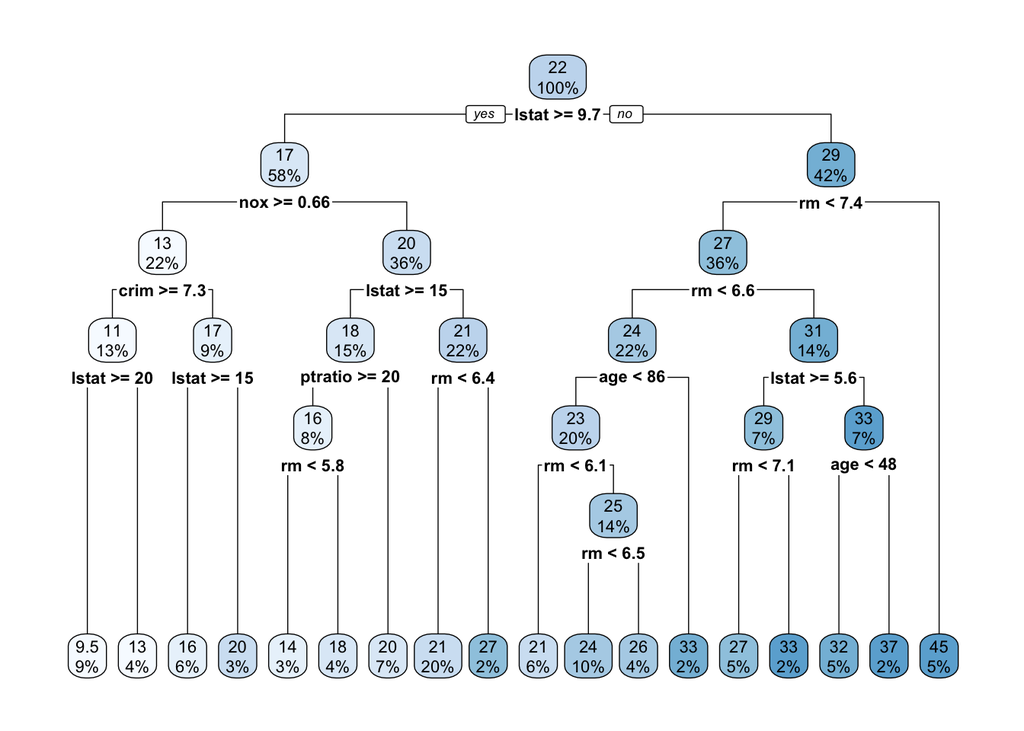

```r
tc = trainControl(method = 'cv', # cross-validation
                  number = 10 # number of K-fold
                  )
cp.grid = expand.grid(cp = seq(0, 0.03, 0.001))
set.seed(123456789)
boston.tree2 = caret::train(Boston_formula,
                            data = data.train,
                            method = 'rpart',
                            trControl = tc,    # list created by caret::trainControl()
                            tuneGrid = cp.grid # a dataframe contain possible tuning values, the columns
                            )                  # are named the same as the tuning parameters
                                               # therefore, here we are tuning parameter cp = tree complexity.
                                               # At the end of the process, we have the optimal model selected using smallest value of RMSE.
                                               # The object is returned of type train of caret.

rpart.plot::rpart.plot(boston.tree2$finalModel)
```

```r
boston.tree2
```

```
## CART
##
## 356 samples
##  13 predictor
##
## No pre-processing
## Resampling: Cross-Validated (10 fold)
## Summary of sample sizes: 321, 319, 320, 320, 321, 320, ...
## Resampling results across tuning parameters:
##
##   cp     RMSE      Rsquared   MAE
##   0.000  4.695060  0.7234262  3.271792
##   0.001  4.676993  0.7243360  3.251638
##   0.002  4.642681  0.7290699  3.218366
##   0.003  4.648172  0.7272722  3.213652
##   0.004  4.676934  0.7246039  3.254344
##   0.005  4.721381  0.7176935  3.331276
##   0.006  4.693797  0.7201709  3.347813
##   0.007  4.728663  0.7144329  3.371596
##   0.008  4.795900  0.7078646  3.435531
##   0.009  4.772393  0.7088851  3.451674
##   0.010  4.804494  0.7049461  3.478532
##   0.011  4.969413  0.6863626  3.486341
##   0.012  4.985444  0.6824714  3.461222
##   0.013  4.990877  0.6818180  3.483684
##   0.014  5.013177  0.6783218  3.489821
##   0.015  5.027409  0.6768197  3.499107
##   0.016  5.100321  0.6678570  3.565204
##   0.017  5.100321  0.6678570  3.565204
##   0.018  5.154987  0.6617878  3.619490
##   0.019  5.145889  0.6611901  3.600181
##   0.020  5.145889  0.6611901  3.600181
##   0.021  5.110264  0.6654152  3.583546
##   0.022  5.117158  0.6643450  3.591980
##   0.023  5.123147  0.6632551  3.600310
##   0.024  5.109352  0.6658594  3.605788
##   0.025  5.050533  0.6731238  3.554611
##   0.026  5.030665  0.6768581  3.555508
##   0.027  5.053257  0.6741979  3.577753
##   0.028  5.053257  0.6741979  3.577753
##   0.029  5.053257  0.6741979  3.577753
##   0.030  5.053257  0.6741979  3.577753
##
## RMSE was used to select the optimal model using the smallest value.
## The final value used for the model was cp = 0.002.
```

## 2.5 Pruning the tree

Eventhough the tree returned by `caret::train()` has lowest MSE, it has too many terminal nodes (high tree complexity). Also previous results show that the values of RMSE, R2 and MAE when cp = 0.03 is not significantly higher compared to the ‘best’ trained model. Therefore, we can try to prune the tree with cp = 0.03

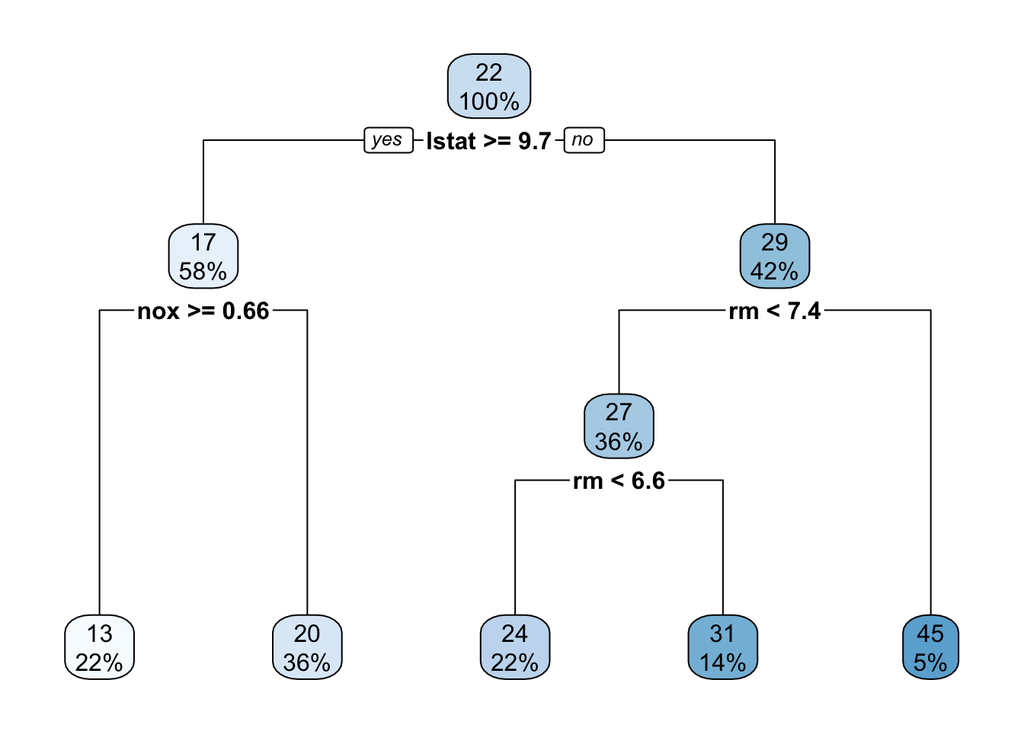

```r
boston.tree2.prune = rpart::prune(boston.tree2$finalModel, cp = 0.03)

rpart.plot::rpart.plot(boston.tree2.prune)
```

## 2.6 Use the tree to predict

Predict and calculate predictions error (R2, MSE, MAE, MedAE,…) using function `regresionMetrics()` defined in source file *regressionMetrics.R*.

```r
regressionMetrics(real = data.test$medv,
                  predicted = predict(boston.tree2.prune, data.test)
                  )
```

```
##        MSE     RMSE      MAE    MedAE     MSLE        R2
## 1 25.32937 5.032829 3.418523 2.378697 0.045792 0.7306393
```

```r
#compared to originally fitted tree
regressionMetrics(real = data.test$medv,
                  predicted = predict(boston.tree, data.test)
                  )
```

```
##        MSE     RMSE      MAE    MedAE       MSLE        R2
## 1 20.54787 4.532976 3.185697 2.311717 0.03463593 0.7814873
```